# 회귀분석

- 회귀분석에 의해 변수 사이의 인과관계가 명확해지고, 한 변수가 다른 변수에 끼치는 영향을 추정할 수 있다.
- 회귀분석에서는 복잡한 현상을 사람이 이해할 수 있을 정도의 간단한 구조로 충분히 설명할 수 있는 모형을 찾는 것이 목적이다.
- 참고 site

  Homepage : https://www.statsmodels.org/stable/index.html

  설명 site : https://datascienceschool.net/view-notebook/77ee0e1bb6754ad89e0da14c6d461953/

```python
import numpy as np
import pandas as pd
import matplotlib.pyplot as plt
from scipy import stats
import statsmodels.formula.api as smf

%precision 3
%matplotlib inline
```

```python
df = pd.read_csv('scores_reg.csv')
n = len(df)
print(n)
df.head()
```

```
20
```

|  | quiz | final_test | sleep_time | school_method |
| --- | --- | --- | --- | --- |
| 0 | 4.2 | 67 | 7.2 | bus |
| 1 | 7.2 | 71 | 7.9 | bicycle |
| 2 | 0.0 | 19 | 5.3 | bus |
| 3 | 3.0 | 35 | 6.8 | walk |
| 4 | 1.5 | 35 | 7.5 | walk |

## 단순회귀모형

- 회귀분석( regression analysis ) : 인과관계가 의심되는 복수의 변수를 사용하여 어느 변수로부터 다른 변수의 값을 예측하는 기법
- 원인이 되는 변수를 설명변수( explanatory variable )라 하고, 결과가 되는 변수를 반응변수( response variable )라 한다.
- 설명변수는 독립변수( independent variable ), 반응변수는 종속변수( dependent variable )라고 부르기도 한다.
- 회귀분석에서 설명변수와 반응변수가 1개씩인 가장 단순한 모델을 단순회귀모형( simple regression model )이라고 한다.

```python
x = np.array(df['quiz'])
y = np.array(df['final_test'])
p = 1
```

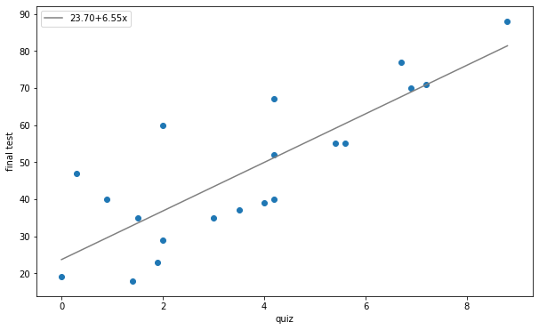

```python
poly_fit = np.polyfit(x, y, 1)
poly_1d = np.poly1d(poly_fit)
xs = np.linspace(x.min(), x.max())
ys = poly_1d(xs)

fig = plt.figure(figsize=(10, 6))
ax = fig.add_subplot(111)
ax.set_xlabel('quiz')
ax.set_ylabel('final test')
ax.plot(xs, ys, color='gray',
        label=f'{poly_fit[1]:.2f}+{poly_fit[0]:.2f}x')
ax.scatter(x, y)
ax.legend()

plt.show()
```

### 회귀분석에서의 가설

- 단순회귀모형에서는 설명변수 x와 반응변수 y 사이에 y = b + WX 관계를 가정한다.
- 기본적인 관계는 직선상에 있다고 생각하고, 다른 요인에 관해서는 에측할 수 없는 확률적인 것이라고 생각한다.
- 예측할 수 없는 부분을 오차항( error term )이라 하고 \begin{equation*} \epsilon_2 \end{equation*} 나타내면

\begin{equation*} Y_i = b + W_iX_i + \epsilon_i ( i = 1, 2, ... , n ) \end{equation*}

- 회귀분석에서는 다음의 두 가지를 가정한다.
  - 설명변수가 확률변수는 아니다.
  - 오차항은 서로 독립이다.

### statsmodels에 의한 회귀분석

- statsmodels에서는 회귀분석을 smf.ols() 함수에 설명변수와 반응변수의 관계를 나타낸 문자열과 DataFrame을 전달하고, 추가로 fit 메서드를 호출하여 실행할 수 있다.

```python
# 반응변수 : final_test, 설명변수 : quiz
formula = 'final_test ~ quiz'
result = smf.ols(formula, df).fit()
result.summary()
```

OLS Regression Results

| Dep. Variable: | final_test | R-squared: | 0.676 |
| --- | --- | --- | --- |
| Model: | OLS | Adj. R-squared: | 0.658 |
| Method: | Least Squares | F-statistic: | 37.61 |
| Date: | Mon, 29 Jun 2020 | Prob (F-statistic): | 8.59e-06 |
| Time: | 10:28:29 | Log-Likelihood: | -76.325 |
| No. Observations: | 20 | AIC: | 156.7 |
| Df Residuals: | 18 | BIC: | 158.6 |
| Df Model: | 1 |  |  |
| Covariance Type: | nonrobust |  |  |

|  | coef | std err | t | P>\|t\| | [0.025 | 0.975] |
| --- | --- | --- | --- | --- | --- | --- |
| Intercept | 23.6995 | 4.714 | 5.028 | 0.000 | 13.796 | 33.603 |
| quiz | 6.5537 | 1.069 | 6.133 | 0.000 | 4.309 | 8.799 |

| Omnibus: | 2.139 | Durbin-Watson: | 1.478 |
| --- | --- | --- | --- |
| Prob(Omnibus): | 0.343 | Jarque-Bera (JB): | 1.773 |
| Skew: | 0.670 | Prob(JB): | 0.412 |
| Kurtosis: | 2.422 | Cond. No. | 8.32 |

Warnings:  
[1] Standard Errors assume that the covariance matrix of the errors is correctly specified.

### 점 추정

- coef에 출력된 회귀계수 추정량 b, W를 실제로 구합니다.
- 이 추정값이 생성한 직선 y = b + WX 즉 회귀직선은 데이터 ( X1y1 ), ( X2y2 ), ..., ( Xnyn )에 가장 잘 들어맞는 직선이다.
- 데이터에 가장 잘 들어맞는 직선이란 \begin{equation*}X_i\end{equation*}로부터 예측된 모형의 예측값( predicted value ) \begin{equation*}\hat{y_i} = \hat{b} + \hat{W}X_i\end{equation*}와 실제의 데이터 \begin{equation*}y_i\end{equation*}의 차이가 가장 작은 직선이다.
- 엄밀하게 \begin{equation*}y_i - \hat{y_i}\end{equation*}를 잔차( residual ) \begin{equation*} \hat{\epsilon_i}\end{equation*}로 하고, 그 제곱합인 잔차제곱합( residual sum of squares, RSS )이 더욱 작은 직선으로서 정의된다.
- 잔차제곱합을 최소화하는 b와 W를 구하는 방법을 최소제곱법( ordinary least squares )이라고 한다.
- 최소제곱법으로 구한 \begin{equation*}\hat{b}와 \hat{W}은\end{equation*} b와 W의 불편일치추정량이 된다고 알려져 있다.

#### 최소제곱법에 의한 b, w 계산 예

```python
X = np.array([np.ones_like(x), x]).T
X
```

```
array([[1. , 4.2],
       [1. , 7.2],
       [1. , 0. ],
       [1. , 3. ],
       [1. , 1.5],
       [1. , 0.9],
       [1. , 1.9],
       [1. , 3.5],
       [1. , 4. ],
       [1. , 5.4],
       [1. , 4.2],
       [1. , 6.9],
       [1. , 2. ],
       [1. , 8.8],
       [1. , 0.3],
       [1. , 6.7],
       [1. , 4.2],
       [1. , 5.6],
       [1. , 1.4],
       [1. , 2. ]])
```

```python
# 최소 제곱법 계산
beta0_hat, beta1_hat = np.linalg.lstsq(X, y)[0]
beta0_hat, beta1_hat
```

```
(23.69949534673122, 6.553732606043082)
```

```python
# 예측값과 잔차 계산
y_hat = beta0_hat + beta1_hat * x
eps_hat = y - y_hat
```

```python
s_var = np.var(eps_hat, ddof=p+1)
s_var
```

```
134.29043473495898
```

### 구간추정

- b, W에 대한 구간추정

```python
# b, W에 대한 표준오차 계산을 위한 대각성분 첫 번째와 두 번째갑
C0, C1 = np.diag(np.linalg.pinv(np.dot(X.T, X)))
```

```python
# b, W의 표준오차
np.sqrt(s_var * C0), np.sqrt(s_var * C1)
```

```
(4.713837012645705, 1.0685841387335373)
```

#### 구간추정 수행

```python
rv = stats.t(n-2)

lcl = beta0_hat - rv.isf(0.025) * np.sqrt(s_var * C0)
hcl = beta0_hat - rv.isf(0.975) * np.sqrt(s_var * C0)
lcl, hcl
```

```
(13.796091272760252, 33.60289942070219)
```

```python
rv = stats.t(n-2)

lcl = beta1_hat - rv.isf(0.025) * np.sqrt(s_var * C1)
hcl = beta1_hat - rv.isf(0.975) * np.sqrt(s_var * C1)
lcl, hcl
```

```
(4.308720637125889, 8.798744574960274)
```

### t 검정

```python
t = beta1_hat / np.sqrt(s_var * C1)
t
```

```
6.133099274532023
```

```python
(1 - rv.cdf(t)) * 2
```

```
8.590875866687497e-06
```

#### b에 대한 가설검정

- 귀무가설 : b == 0
- 대립가설 : b != 0

```python
t = beta0_hat / np.sqrt(s_var * C0)
t
```

```
5.027644206440129
```

```python
(1 - rv.cdf(t)) * 2
```

```
8.745298393186829e-05
```

## 다중선형회귀모형( 중회귀모형, multiple regression model )

- 설명변수가 2개 이상인 모형

### statsmodels에 의한 회귀분석

- statsmodels에서는 회귀분석을 smf.ols() 함수에 설명변수를 +로 연결한 문자열을 전달한다.

```python
formula = 'final_test ~ quiz + sleep_time'
result = smf.ols(formula, df).fit()
result.summary()
```

OLS Regression Results

| Dep. Variable: | final_test | R-squared: | 0.756 |
| --- | --- | --- | --- |
| Model: | OLS | Adj. R-squared: | 0.727 |
| Method: | Least Squares | F-statistic: | 26.35 |
| Date: | Mon, 29 Jun 2020 | Prob (F-statistic): | 6.19e-06 |
| Time: | 11:00:54 | Log-Likelihood: | -73.497 |
| No. Observations: | 20 | AIC: | 153.0 |
| Df Residuals: | 17 | BIC: | 156.0 |
| Df Model: | 2 |  |  |
| Covariance Type: | nonrobust |  |  |

|  | coef | std err | t | P>\|t\| | [0.025 | 0.975] |
| --- | --- | --- | --- | --- | --- | --- |
| Intercept | -1.8709 | 11.635 | -0.161 | 0.874 | -26.420 | 22.678 |
| quiz | 6.4289 | 0.956 | 6.725 | 0.000 | 4.412 | 8.446 |
| sleep_time | 4.1917 | 1.778 | 2.357 | 0.031 | 0.440 | 7.943 |

| Omnibus: | 2.073 | Durbin-Watson: | 1.508 |
| --- | --- | --- | --- |
| Prob(Omnibus): | 0.355 | Jarque-Bera (JB): | 1.716 |
| Skew: | 0.660 | Prob(JB): | 0.424 |
| Kurtosis: | 2.437 | Cond. No. | 38.0 |

Warnings:  
[1] Standard Errors assume that the covariance matrix of the errors is correctly specified.

### 회귀계수

```python
x1 = df['quiz'] # 설명변수 : 쪽지 시험
x2 = df['sleep_time'] # 설명변수 : 수면 시간
y = df['final_test'] # 반응변수 : 기말고사
p = 2
```

```python
# W1, W2, W3 값 계산
X = np.array([np.ones_like(x1), x1, x2]).T
beta0_hat, beta1_hat, beta2_hat = np.linalg.lstsq(X, y)[0]
beta0_hat, beta1_hat, beta2_hat
```

```
(-1.8709143470995908, 6.42887834300237, 4.191706546398685)
```

```python
# 예측값 y 계산 및 y와 예측값 y의 잔차
y_hat = beta0_hat + beta1_hat * x1 + beta2_hat * x2
eps_hat = y - y_hat
```

```python
# 표준 오차 계산
s_var = np.sum(eps_hat ** 2) / (n - p - 1)
C0, C1, C2 = np.diag(np.linalg.pinv(np.dot(X.T, X)))
```

```python
# 수면 시간에 대한 W2의 95% 신뢰구간 계산
rv = stats.t(n-p-1)

lcl = beta2_hat - rv.isf(0.025) * np.sqrt(s_var * C2)
hcl = beta2_hat - rv.isf(0.975) * np.sqrt(s_var * C2)
lcl, hcl
```

```
(0.440253332543481, 7.943159760253889)
```

### 가변수( dummy variable )

- 통학 방법( school_method )와 같은 범주형 변수를 연속형 변수와 동일하게 취급할 수 있게 하는 기법을 도입하는 것이 좋은데 이런 기법을 가변수( dummy variable )라 하고, one-hot encoding이라한다.
- 범주형 변수를 일부러 연속형 변수로 변환하는 것은 번거로울 수 있는데, statsmodels에서는 이러한 작업을 자동으로 수행해 준다.
- 설명변수를 쪽지 시험과 수면 시간과 통학 방법으로 한 다중선형회귀 모형으로 회귀분석을 수행할 때 회귀모형은 다음과 같다.

\begin{equation*} Y_i = b + W_1X_{i1} + W_2X_{i2} + W_3X_{i도보} + W_4X_{i자전거} + \epsilon_i \end{equation*}

```python
formula = 'final_test ~ quiz + sleep_time + school_method'
result = smf.ols(formula, df).fit()
result.summary()
```

OLS Regression Results

| Dep. Variable: | final_test | R-squared: | 0.782 |
| --- | --- | --- | --- |
| Model: | OLS | Adj. R-squared: | 0.724 |
| Method: | Least Squares | F-statistic: | 13.46 |
| Date: | Mon, 29 Jun 2020 | Prob (F-statistic): | 7.47e-05 |
| Time: | 19:24:25 | Log-Likelihood: | -72.368 |
| No. Observations: | 20 | AIC: | 154.7 |
| Df Residuals: | 15 | BIC: | 159.7 |
| Df Model: | 4 |  |  |
| Covariance Type: | nonrobust |  |  |

|  | coef | std err | t | P>\|t\| | [0.025 | 0.975] |
| --- | --- | --- | --- | --- | --- | --- |
| Intercept | 1.3330 | 12.434 | 0.107 | 0.916 | -25.169 | 27.835 |
| school_method[T.bus] | -1.8118 | 6.324 | -0.286 | 0.778 | -15.292 | 11.668 |
| school_method[T.walk] | -7.6555 | 6.420 | -1.192 | 0.252 | -21.339 | 6.028 |
| quiz | 6.0029 | 1.033 | 5.809 | 0.000 | 3.800 | 8.206 |
| sleep_time | 4.5238 | 1.809 | 2.501 | 0.024 | 0.668 | 8.380 |

| Omnibus: | 1.764 | Durbin-Watson: | 1.418 |
| --- | --- | --- | --- |
| Prob(Omnibus): | 0.414 | Jarque-Bera (JB): | 0.989 |
| Skew: | 0.545 | Prob(JB): | 0.610 |
| Kurtosis: | 2.985 | Cond. No. | 41.8 |

Warnings:  
[1] Standard Errors assume that the covariance matrix of the errors is correctly specified.

## 모형의 선택

- 회귀분석으로 만든 모형은 크게 두가지로
  1. 적합이 좋은 것
  2. 예측이 좋은 것
- 적합이 좋다는 것은 모형이 주변에 있는 데이터에 어느 정도 들어맞는다는 것이다. 회귀직선이 데이터에 완전하게 들어맞고 잔차가 작으면 그 모형은 좋은 모형이라고 할 수 있다.
- 예측이 좋다는 것은 주변에 있는 데이터로 만든 모형이 미지의 데이터를 어느 정도 예측할 수 있다는 것이다. 모르는 데이터의 설명변수라도 모형이 반응변수를 정확하게 예측할 수 있다면 그것은 좋은 모형이라고 할 수 있다.
- 적합이 좋다는 것은 설명변수를 증가시켜 가는 것만으로 간단하게 달성된다. 하지만 예측 정확도가 떨어진다. 이것은 과적합( overfitting )이라고 부르는 문제로, 매우 복잡한 모형은 표현력이 너무 높은 나머지 주변 데이터에 지나치게 적합되어 일반적인 예측성을 잃어버리는 것이다. 이 때문에 *모형을 고를 때는 모통 적합도가 좋은 것보다 예측 정확도가 좋은 것*을 고르게 된다.
- 모형의 좋고 나쁨을 측정하는 여러 지표는 statsmodels 분석 결과중 coef 윗 부분에 출력된다.

```python
x = np.array(df['quiz'])
y = np.array(df['final_test'])
p = 1

formula = 'final_test ~ quiz'
result = smf.ols(formula, df).fit()
result.summary()
```

OLS Regression Results

| Dep. Variable: | final_test | R-squared: | 0.676 |
| --- | --- | --- | --- |
| Model: | OLS | Adj. R-squared: | 0.658 |
| Method: | Least Squares | F-statistic: | 37.61 |
| Date: | Mon, 29 Jun 2020 | Prob (F-statistic): | 8.59e-06 |
| Time: | 11:30:05 | Log-Likelihood: | -76.325 |
| No. Observations: | 20 | AIC: | 156.7 |
| Df Residuals: | 18 | BIC: | 158.6 |
| Df Model: | 1 |  |  |
| Covariance Type: | nonrobust |  |  |

|  | coef | std err | t | P>\|t\| | [0.025 | 0.975] |
| --- | --- | --- | --- | --- | --- | --- |
| Intercept | 23.6995 | 4.714 | 5.028 | 0.000 | 13.796 | 33.603 |
| quiz | 6.5537 | 1.069 | 6.133 | 0.000 | 4.309 | 8.799 |

| Omnibus: | 2.139 | Durbin-Watson: | 1.478 |
| --- | --- | --- | --- |
| Prob(Omnibus): | 0.343 | Jarque-Bera (JB): | 1.773 |
| Skew: | 0.670 | Prob(JB): | 0.412 |
| Kurtosis: | 2.422 | Cond. No. | 8.32 |

Warnings:  
[1] Standard Errors assume that the covariance matrix of the errors is correctly specified.

```python
# 예측값 y 계산 : result.fittedvalues 변수에 예측값 y가 저장
y_hat = np.array(result.fittedvalues)
y_hat
```

```
array([51.225, 70.886, 23.699, 43.361, 33.53 , 29.598, 36.152, 46.638,
       49.914, 59.09 , 51.225, 68.92 , 36.807, 81.372, 25.666, 67.61 ,
       51.225, 60.4  , 32.875, 36.807])
```

```python
# 예측값 y의 잔차 : result.resid 변수에 예측값 y의 잔차가 저장
eps_hat = np.array(result.resid)
eps_hat
```

```
array([ 15.775,   0.114,  -4.699,  -8.361,   1.47 ,  10.402, -13.152,
        -9.638, -10.914,  -4.09 , -11.225,   1.08 ,  -7.807,   6.628,
        21.334,   9.39 ,   0.775,  -5.4  , -14.875,  23.193])
```

```python
# 잔차 제곱합 계산
np.sum(eps_hat ** 2)
```

```
2417.227825229262
```

### 결정계수( R-squared )

- 모형의 데이터에 대한 적합도를 나타내는 기본적인 지표
- 결정계수는 R의 제곱으로 표기하고, statsmodels의 결과에는 R-squared로 출력된다.
- 결정계수는 0 ~ 1 사이의 값을 취하고, 1에 가까울수록 모델은 데이터에 잘 들어맞는다고 생각할 수 있다.
- 결정계수를 구하려면 총변동, 회귀변동, 잔차변동이라는 세 가지 변동에 대해 알아야 한다.
  - 총변동( total variation ) : 관측값 y가 어느 정도 분산되어 있는지를 나타내는 지표
  - 회귀변동( regression variation ) : 예측값 y가 관측값의 평균값에 대해서 어느 정도 분산되어 있는지를 나타내는 지표
  - 잔차변동( residual variation ) : 잔차의 산포도를 나타내는 지표
- 세 가지 변동에는 다음과 같은 관계가 성립된다.

  총 변동 = 회귀변동 + 잔차변동
- 결정계수는 다음과 같이 계산할 수 있다.

\begin{equation*} R^2 = \frac {회귀변동}{총변동} = 1 - \frac {잔차변동}{총변동} \end{equation*}

```python
total_var = np.sum((y - np.mean(y))**2) # 총변동
exp_var = np.sum((y_hat - np.mean(y))**2) # 회귀변동
unexp_var = np.sum(eps_hat ** 2) # 잔차변동
```

```python
# 총변동 = 회귀변동 + 잔차변동의 관계가 성립하는지 확인
total_var, exp_var + unexp_var
```

```
(7468.55, 7468.549999999996)
```

```python
# 결정계수 계산 : 단순회귀의 결정계수는 설명변수와 반응변수의 상관계수 제곱과 일치한다고 알려져 있다.
exp_var / total_var
```

```
0.6763457665504996
```

```python
# 상관계수 제곱
np.corrcoef(x, y)[0, 1] ** 2
```

```
0.6763457665504998
```

#### 모델 적합도가 가장 좋음 모형

- statsmodels 실행 결과에서 R-squared로부터 얻은 각 회귀계수 값 정리
- 기말고사~쪽지시험 : 0.676
- 기말고사~쪽지시험 + 수면시간 : 0.756
- 기말고사~쪽지시험 + 수면시간 + 통학방법 : 0.782
- 결정계수를 지준으로 하면, 변수가 전부 들어간 모형의 적합도가 가장 좋다.
- 실은 별 의미 없는 변수가 들어간다 해도 설명변수가 증가하면 결정계수가 증가하는 것으로 알려져 있다.
- 이와 같은 문제를 해결하는 것이 조정결정계수이다.

### 조정결정계수( adjusted R-square )

- 설명변수를 추가했을 때 그 설명변수에 어느 정도 이상의 설명력이 없는 경우 결정계수의 값이 증가하지 않도록 조정하는 결정계수이다.
- 조정결정계수는 R 제곱의 바 로 포기하고, statsmodels의 분석 결과에는 adj. R-squred로 출력된다.
- 조정결정계수는 자유도조정 결정계수라고도 한다. 이름 그대로 자유도를 고려한 결정계수이다.
- 잔차변동과 총변동을 각각 자유도로 나누어 조정결정계수를 계산한다.

\begin{equation*} \overline{R^2} = 1 - \frac {잔차변동 / n - p - 1}{총변동 / n - 1 } \end{equation*}

```
- 총 변동의 자유도는 회귀계수의 수에 상관업이 항상 n - 1이 된다.
- 잔차변동의 자유도는 n - p - 1, 회귀변동의 자유도는 회귀계수의 수가 된다.


총변동의 자유도 = 회귀변동의 자유도 + 잔차변동의 자유도
```

- 를 만족한다.
- 회귀변동의 자유도는 모형의 자유도라고도 부르고, statsmodels의 분석 결과에는 Df Model로 출력된다.
- 잔차변동의 자유도는 잔차의 자유도라고도 부르고, Df Residual로 출력된다.

```python
# 단순회귀모형의 조정결정계수 계산 - 기말고사~쪽지시험
1 - (unexp_var / (n - p - 1)) / (total_var / (n - 1))
```

```
0.6583649758033057
```

- 각 모형의 조정결정계수는 다음과 같다.
  - 기말고사 ~ 쪽지시험 : 0.658
  - 기말고사 ~ 쪽지시험 + 수면시간 : 0.727
  - 기말고사 ~ 쪽지시함 + 수면시간 + 통학방법 : 0.724
- 조정결정계수를 기준으로 하면, 설명변수를 쪽지 시험과 수면 시간으로 한 모델의 적합도가 가장 높다.

### F검정( F-test )

- 절편 b 이외의 회귀계수에 관해서 다음과 같은 가설로 수행되는 검정
  - 귀무가설 : W1 = W2 = ... = Wp = 0
  - 대립가설 : 적어도 하나의 W은 0이 아니다.
- F 검정은 t 검정과 같이 개개의 회귀계수에 대해서가 아니라, 모형 전체에 대해서 수행된다.
- F 검정통계량은 statsmodels 분석 결과의 F-statistic에, 그 P 값은 Prob( F-statistic )에 출력된다.
- F 검정통계량은 다음과 같이 계산되고, 자유도가 ( p, n - p - 1 )인 F 검정을 따른다.

\begin{equation*} F = \frac {회귀변동 / p}{잔차변동 / ( n - p - 1 ) } \end{equation*}

- F 검정의 이론은 회귀분석의 경우와 비슷하게, 모형의 적합도가 좋을수록 잔차변동보다 회귀변동이 커지는 것을 이용한다.
- F 검정통계량이 어떤 값보다 커진 경우, 모형이 데이터에 적합되어 있다고 생각할 수 있고, 상단의 단측검정을 수행하여 모형 전체에 관한 가설검정을 수행할 수 있다.
- F 검정통계량의 분모와 분자는 각각 잔차변동을 그 자유도로 나눈 것과 회귀변동을 그 자유도로 나눈 것으로 되어 있고, 이것들은 각각 잔차의 분산과 모형의 분산이라고 생각할 수 있다.
- F 검정통계량은 분산의 비를 검정하고 있다고 해석할 수 있다.
- 이 검정을 분산분석( analysis of variance, ANOVA )이라고도 부른다.

```python
# F 검정통계량 계산
f = (exp_var / p)  / (unexp_var / (n - p - 1))
f
```

```
37.61490671126522
```

```python
# F 검정통계량에 대응하는 p값 계산
rv = stats.f(p, n-p-1)
1 - rv.cdf(f)
```

```
8.590875866687497e-06
```

### 최대 로그 우도와 AIC

```python
# 우도 계산
prob = 0.3
coin_result = [0, 1, 0, 0, 1]

rv = stats.bernoulli(prob)
L = np.prod(rv.pmf(coin_result))
L
```

```
0.030870000000000005
```

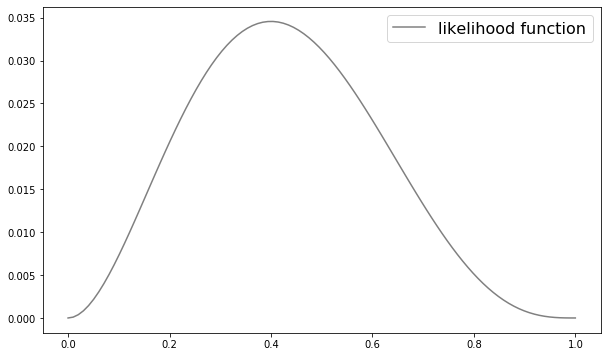

```python
# L( p )에서 p를 0에서 1로 변화시킬 때의 우도함수 시각화
ps = np.linspace(0, 1, 100)
Ls = [np.prod(stats.bernoulli(prob).pmf(coin_result))
      for prob in ps]

fig = plt.figure(figsize=(10, 6))
ax = fig.add_subplot(111)
ax.plot(ps, Ls, label='likelihood function', color='gray')
ax.legend(fontsize=16)
plt.show()
```

- 이산형( 범주형 ) 확률변수에 대하여
- 위의 그래프에서 우도함수는 p가 0.4일 때 최대가 되는 것 같다.
- 이것은 관측값에 의해 p = 0.4가 가장 그럴 듯한 모수라고 바꿔 말할 수 있다.
- 모수 p를 추정하는 방법을 최우추정법( method of maximum likelihood )이라고 한다.
- 최우추정법에 의해 추측되는 추정량을 최우추정량( maximum likelihood estimator )
- 그 추정값을 최우추정값( maximum likelihood estimate )이라고 한다.
- 연속형 확률변수에서도 우도를 정의할 수 있다.
- f( x )가 이산형 확률변수에서는 확률함수, 연속형 확률변수에서는 확률밀도함수라고 하면,
- 다음 정의는 어떤 경우에도 대응되는 우도의 정의이다.

\begin{equation*} L = \prod_{i=1} f(x_i) \end{equation*}

- 우도는 확률의 곱이 되므로, 곱하면 곱할수록 0에 가까워진다. 이와 같은 작은 값은 수작업/컴퓨터 모두 어려우므로  
  우도에 로그를 취한 로그우드( log-likelihood )가 대신 사용되곤 한다.

\begin{equation*} log L = \sum_{i=0} log f(x_i) \end{equation*}

- 우도함수가 최대로 될 때 로그우드함수도 최대가 되므로, 최우추정은 로그우드함수가 최대가 될 때의  
  파라미터로서 구할 수 있다. 그때의 로그우드의 값을 최대로그우드( maximum log-likelihood )라고 한다.

```python
# 동전의 최대로그우드 계산, p의 최우추정값은 0.4였으므로 p = 0.4로 했을 때의 로그우드가 최대로그우드가 된다.
prob = 0.4
rv = stats.bernoulli(prob)
mll = np.sum(np.log(rv.pmf([0, 1, 0, 0, 1])))
mll
```

```
-3.365058335046282
```

#### 최대로그우드

- statsmodels의 출력 결과에서 Log-Likelihood에 출력된다.

```python
# 최대로그우드 계산
rv = stats.norm(y_hat, np.sqrt(unexp_var / n))
mll = np.sum(np.log(rv.pdf(y)))
mll
```

```
-76.32521428624038
```

#### AIC

- 로그우드는 모형의 적합도를 나타내지만, 그 지표는 의미 없는 설명변수를 늘림으로써 값이 증가한다.
- 로그우드와 같이 적합도를 기준으로 하면 일반 성능이 나쁜 모형이 선택되고 만다.
- 이 때문에 모형의 복잡도( 설명변수의 수 )와 데이터에 대한 적합도의 균형을 잡는 지표가 필요하다.
- AIC( Akaike's information criterion )는 일반적인 성능도 고려하여 넣은 지표이므로, 예측이 좋은 것을 나타내는 지표라 할 수 있다.
- 실제로 모형을 선택할 때 이 AIC에 의해 수행되는 경우가 많다.
- AIC를 구하는 방식은 다양하지만, statsmodels의 출력에 맞추어 다음과 같이 정의한다.

  ```
    AIC = -2 X 최대로그우도 + 2 X 회귀계수의 수
  ```

- AIC는 최대로그우드에 회귀계수의 수를 패널티로 부가하여 무턱대고 설명변수를 늘린 모형이 좋은 모형으로 선택되지 않게끔 한다고 해설할 수 있다.
- AIC는 값이 작을수록 모형의 예측 정확도가 좋다고 생각할 수 있다.
  - 기말고사~쪽지시험 : 156.7
  - 기말고사~쪽지시험 + 수면시간 : 153.0
  - 기말고사~쪽지시험 + 수면시간 + 통학방법 : 154.7
- AIC를 기준으로 하면, 설명변수에 쪽지 시험과 수면 시간을 이용하는 모형이 가장 좋은 모형이 된다.

```python
# AIC 계산
aic = -2 * mll + 2 * (p+1)
aic
```

```
156.65042857248076
```

#### 베이시안 정보 기준( Bayesian information criterion, BIC )

- AIC와 유사한 지표이다.
- BIC는 회귀계수의 수에 더해 표본 크기 n에 대해서도 패널티를 부가한 것이다.

  BIC =- -2 X 최대로그우드 + log n X 회귀계수의 수
- BIC도 AIC와 마찬가지로 값이 작을수록 모형의 예측 정확도가 좋다고 생각할 수 있다.
  - 기말고사~쪽지시험 : 158.6
  - 기말고사~쪽지시험 + 수면시간 : 156.0
  - 기말고사~쪽지시험 + 수면시간 + 통학방법 : 159.7
- BIC를 기준으로 하면, 설명변수로 쪽지 시험과 수면 시간을 이용하는 모형이 가정 좋은 모형이 된다.

```python
# BIC 계산
bic = -2 * mll + np.log(n) * (p+1)
bic
```

```
158.64189311958876
```

## 모형의 타당성

- statsmodels에서는 분석 결과의 아래 부분에 모형의 타당성에 관한 정보가 출력된다.

```python
formula = 'final_test ~ quiz + sleep_time'
result = smf.ols(formula, df).fit()
result.summary()
```

OLS Regression Results

| Dep. Variable: | final_test | R-squared: | 0.756 |
| --- | --- | --- | --- |
| Model: | OLS | Adj. R-squared: | 0.727 |
| Method: | Least Squares | F-statistic: | 26.35 |
| Date: | Mon, 29 Jun 2020 | Prob (F-statistic): | 6.19e-06 |
| Time: | 15:59:43 | Log-Likelihood: | -73.497 |
| No. Observations: | 20 | AIC: | 153.0 |
| Df Residuals: | 17 | BIC: | 156.0 |
| Df Model: | 2 |  |  |
| Covariance Type: | nonrobust |  |  |

|  | coef | std err | t | P>\|t\| | [0.025 | 0.975] |
| --- | --- | --- | --- | --- | --- | --- |
| Intercept | -1.8709 | 11.635 | -0.161 | 0.874 | -26.420 | 22.678 |
| quiz | 6.4289 | 0.956 | 6.725 | 0.000 | 4.412 | 8.446 |
| sleep_time | 4.1917 | 1.778 | 2.357 | 0.031 | 0.440 | 7.943 |

| Omnibus: | 2.073 | Durbin-Watson: | 1.508 |
| --- | --- | --- | --- |
| Prob(Omnibus): | 0.355 | Jarque-Bera (JB): | 1.716 |
| Skew: | 0.660 | Prob(JB): | 0.424 |
| Kurtosis: | 2.437 | Cond. No. | 38.0 |

Warnings:  
[1] Standard Errors assume that the covariance matrix of the errors is correctly specified.

```python
# 잔차
eps_hat = np.array(result.resid)
```

### 정규성의 검정

- statsmodels에서는 정규성 검증으로 Omnibus 검정과 Jarque-Bera 검증이 사용된다.
- 이러한 검정통계량은 Omnibus와 Jarque-Bera( JB )에 각각 출력되어 있다.
- 이러한 검정은 모두
  - 귀무가설 : 잔차항은 정규분포를 따른다.
  - 대립가설 : 잔차항은 정규분포를 따르지 않는다.
- 라는 가설검정을 수행한다.
- 결국 이러한 검정의 p값인 Prob( Omnibus ) 나 Prob( JB )가 유의 수준인 0.05보다 크면 문제될 게 없다.
- Skew( 외도 ), Kurtosis( 첨도 )를 나타내고, 평균이나 분산과 마찬가지로 데이터의 특징을 나타내는 지표이다.
- 이러한 지표를 살펴보는 것으로도 정규성을 확인할 수 있다.

#### 왜도( skewness )

- 분포의 좌우대칭을 측정하는 지표

\begin{equation*} \sum_{i}^{n} \left ( \frac{x- \bar x}{S} \right )^3 \end{equation*}

- 왜도는 정규분포와 같이 좌우대칭인 분포이면 0이 되고, 카이제곱분포와 같이 왼쪽으로 치우친 분포이면 0보다 크고,
- 반대로 오른쪽으로 치우친 분포일 때에는 0보다 작은 값이 됩니다.
- 이 때문에 왜도를 살펴봄으로써 분포가 좌우대칭인지 여부를 판단할 수 있다.
- 왜도는 stats.skew로 계산할 수 있다.

```python
# 왜도
stats.skew(eps_hat)
```

```
0.660
```

#### 첨도( kurtosis )

- 분포의 뽀족한 정도를 측정하는 지표

\begin{equation*} \sum_{i}^{n} \left ( \frac{x- \bar x}{S} \right )^4 \end{equation*}

- 첨도는 정규분포이면 3이 되고, 정규분포보다 뽀족한 정점을 가진 분포라면 3보다 크고,
- 정규분포보다 둥근 정점을 가진 분포라면 3보다 작은 값이 된다.
- 정규분포의 첨도가 3이므로 경우에 따라서는 위에 제시한 정의에서 3을 뺀 것을 첨도로 하는 경우가 있다.
- statsmodels의 출력에서는 정규분포의 첨도가 3이 되는 정의를 출력한다.
- 첨도는 stats.kurtosis의 인수 fisher를 False로 함으로써 정의할 수 있다.

```python
# 첨도
stats.kurtosis(eps_hat, fisher=False)
```

```
2.437
```

### 더빈-왓슨비( Durbin-Watson ratio )

- 다른 오차항이 서로 무상관인지 여부를 체크하는 지표
- 다루고 있는 데이터가 *시계열 데이터*인 경우에 특히 중요한 데이터이다.
- 더빈-왓슨비의 계산 공식

[figure not shown]

- 더빈-왓슨비는 0부터 4의 값이 되고, 0에 가까우면 양의 상관, 4에 가까우면 음의 상관, 2 앞뒤의 값이면 무상관이라고 판단한다.

```python
# 더빈-왓슨비 계산
np.sum(np.diff(eps_hat, 1) ** 2) / np.sum(eps_hat ** 2)
```

```
1.5082185264423018
```

### 다중공선성

- 마지막 지표는 Cond. No.이며, 이것은 조건수라고 부르는 것이므로 다중공신성을 체크하는 지표이다.
- 조건수의 값이 크면 다중공선성과 설명변수 사이에 강한 상관이 생겼다는 것을 의미한다.
- 다중공선성이 크면 회귀계수의 분산이 커져 모형의 예측 결과가 나빠진다고 알려져 있다.

```python
# 쪽지 시험의 결과를 단지 2배로 한 것뿐인 중간고사라는 변수를 추가했을 때
# 쪽지 시험과 중간고사의 상관관계는 1이 되고 이 데이터는 큰 다중공선성을 가진다.
df['mid_test'] = df['quiz'] * 2
df.head()
```

|  | quiz | final_test | sleep_time | school_method | mid_test |
| --- | --- | --- | --- | --- | --- |
| 0 | 4.2 | 67 | 7.2 | bus | 8.4 |
| 1 | 7.2 | 71 | 7.9 | bicycle | 14.4 |
| 2 | 0.0 | 19 | 5.3 | bus | 0.0 |
| 3 | 3.0 | 35 | 6.8 | walk | 6.0 |
| 4 | 1.5 | 35 | 7.5 | walk | 3.0 |

- 아래 결과에서 조건수가 1.30e+16이라는 매우 큰 값이 되었다.
- 이와 같이 다중공선성이 생기면 조건수는 매우 큰 값이 된다.
- 조건수가 꽤 큰 값이 되어 있을 때는 다중공선성을 의심해보는 것이 좋다.
- 그리고 그 경우에는 설명변수 중에서 한쪽 변수를 모형에서 제외하는 것이 해결책으로 생각할 수 있다.

```python
formula = 'final_test ~ quiz + mid_test'
result = smf.ols(formula, df).fit()
result.summary()
```

OLS Regression Results

| Dep. Variable: | final_test | R-squared: | 0.676 |
| --- | --- | --- | --- |
| Model: | OLS | Adj. R-squared: | 0.658 |
| Method: | Least Squares | F-statistic: | 37.61 |
| Date: | Thu, 13 Feb 2020 | Prob (F-statistic): | 8.59e-06 |
| Time: | 11:57:40 | Log-Likelihood: | -76.325 |
| No. Observations: | 20 | AIC: | 156.7 |
| Df Residuals: | 18 | BIC: | 158.6 |
| Df Model: | 1 |  |  |
| Covariance Type: | nonrobust |  |  |

|  | coef | std err | t | P>\|t\| | [0.025 | 0.975] |
| --- | --- | --- | --- | --- | --- | --- |
| Intercept | 23.6995 | 4.714 | 5.028 | 0.000 | 13.796 | 33.603 |
| quiz | 1.3107 | 0.214 | 6.133 | 0.000 | 0.862 | 1.760 |
| mid_test | 2.6215 | 0.427 | 6.133 | 0.000 | 1.723 | 3.519 |

| Omnibus: | 2.139 | Durbin-Watson: | 1.478 |
| --- | --- | --- | --- |
| Prob(Omnibus): | 0.343 | Jarque-Bera (JB): | 1.773 |
| Skew: | 0.670 | Prob(JB): | 0.412 |
| Kurtosis: | 2.422 | Cond. No. | 1.30e+16 |

Warnings:  
[1] Standard Errors assume that the covariance matrix of the errors is correctly specified.  
[2] The smallest eigenvalue is 1.16e-29. This might indicate that there are  
strong multicollinearity problems or that the design matrix is singular.